# Everything (Mostly) You Need to Know About UAPs According to One Who Actually Has Them

> Three things cannot remain long hidden: The Sun, the Moon, and the Truth - Buddha.

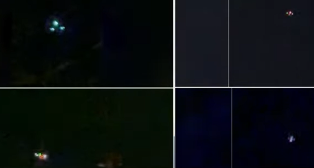

Drone screenshot, CBS News, Dec 2024

**We’ve all been lied to for years and years.**

It’s becoming a well known fact, a trickle now, but cracks in the dam are forming fast. This article, a revelation maybe to some, perhaps utter nonsense to others (and to the latter, stay tuned) delves into a subject matter that I was going to write a few articles later, but due to the recent flurry of hype, misinformation, drones and such, I’m jumping in right now. **There’s no such thing as alone in this universe. There’s no such thing as alone on this earth.** This planet and many others have been destinations for the ages long before the existence, or more accurately it’s been said (keep reading), the creation of humans on earth. And nope, I’m not smoking anything.

Reportedly, around the year 2000 a man known only as E.F. was living in a remote house near southern Sweden. One day he met an attractive brown-haired woman, at least that’s what his mind understood her to be, but she was not as she appeared. Supposedly, one day E.F. violently freaked out and eventually calmed down when the woman, the name she uses is Lacerta, revealed her true physicality. Where she’s from, her function so to speak is to research our social systems, but also provide samples for environmental testing. It turns out that she is from right here, the planet we call home.

**The main points I’m pulling out about below are the very tip of the iceberg.**

A link to the must read interview, 41 pages, is [here.](https://www.bibliotecapleyades.net/vida_alien/esp_vida_alien_52.htm) E.F. recruited his friend known as Ole K. to conduct the interview.

- She is not a human. She is not even a mammal. She is a non-human reptoid with some mammalian characteristics, as she says due to evolution. *Lacerta in Latin translates to lizard in English*.
- She agreed to be interviewed and sketched on paper, not photographed, because she knew that her existence would not be believed and after the first interview wanted the reaction of Ole K’s internet public. There were two interviews in one document. See the link above.
- They are telepathic and capable of telekinesis, whereas both require practice although mother and offspring are telepathic before birth. Their language is unpronounceable to us with many consonants.
- She called her species Terrans, and that they are native to Earth. Her species predates homo sapiens by many millions of years. Earth is actually ‘their’ home.
- That they are not a threat to humans, but that some extraterrestrial aliens are. And as far a she is aware, there are 14 other extraterrestrial species on the planet as of 2000. Three of the 14 are hostile to humans.
- There are other species far more advanced than them. Some are capable of passing through what we call dimensions.
- That real evolution from animal to advanced cognition takes many millions of years. That is the way it is in nature. It took them many tens of millions of years to achieve advanced cognition and capabilities, but that later in their timeline here on Earth they modified their species through genetic engineering.
- That our human timeline from basic simian creatures to advanced cognition is impossibly fast because humans were genetically engineered by another far more advanced interstellar species, The Illojim. Their purpose for creating humans is not fully understood by the Terrans but they did not interfere. There was no threat to the Terrans. Both the Illojim and the Terrans interacted respectfully for a very long time until they didn’t.
- Eventually, conflict began internally within Illojim groups first and then involved the Terrans until a war erupted. The Illojim left. Aliens have conducted wars.
- **She warns of a rumor about an alien war coming here in 10 to 30 years. That’s about now by the way.**
- The Illojim designed our brains with a receptor (switch) that allows the perception of a human to be induced instead of her true reptilian form. Most other alien species also use this switch.
- The modern human is the 6th configuration of human. There were 5 others before us, purposely made extinct by the IIlojim. She doesn’t want to see us destroyed.

**THE REAL McCOY UAPs - According to Lacerta**

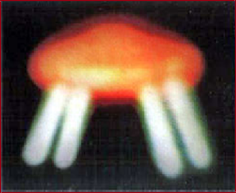

Albiosc, France, 1974

- Most of the fuzzy, morphed-looking images of UAPs are the real ones. It’s the bane of so many uninformed UFO researchers and skeptics, “Why can’t we ever get clear images?”
- They appear so distorted because the power, motion, and anti-gravity systems affect spacetime around them and as a result light bends showing strange shapes and phases of light effects such as the bluish, plasma-like glow often seen.
- Some so-called UAPs actually are weather related or atmospheric anomalies that look like the real ships.

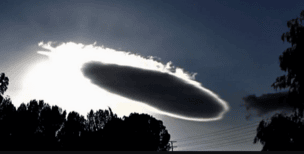

Lenticular cloud formation

- The Terran fleet is mostly cigar-shaped, yet they possess a few disk-shaped craft. Their cigar-shaped ships have 5 red lights: 1 at the top, 1 on each end, and 1 on each side.

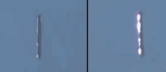

Odd cylindrical craft

- The Triangle-shaped crafts, like below, are ours - sort of.

**THE TRIANGLE CRAFTS - A lopsided joint effort**

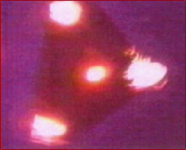

Petit Rechain, Belgium, 1990

According to Lacerta, these are the result of alien-human interaction, the meat and potatoes of the **Disclosure Controversy**. Visitations were made and are still occurring. Top secret deals were made. Bad trades involving living humans were made and alien technology was exchanged. She also says that our governments were easily duped as fools agreeing to one-sided arrangements where they thought that they were receiving the Real Mc Coy tech. What we got were wild goose chases down inferior rabbit holes utilizing dangerous, unstable materials and technology that we barely comprehend. She also says that genuine alien crafts do not need sharp geometric angles to do what they do but apparently ours do because of sham design. There was supposedly a struggle in the US between them and the secret black ops guys and they left us holding a purposely imperfect bag. They supposedly left. The result are the triangular craft showing up all over the place spewing dangerous radiation and probably worse. In fact, she mentions and event that destroyed multiple human lives in close proximity to a badly shielded drive system.

**We were played by our own greed and desire for absolute power.**

Disclosure may fix a lot of that, but a group of experts addressing congress stating that they can’t say this or that, or show this or that artifact won’t help. We need the real thing. All of it. The real beings. The crafts. The tech. **It sounds like a Truth and Reconciliation decree is in order to get this on the table.** We can handle it. Those industries that would quickly disappear and be replaced should maybe find something else to do rather than destroying the planet, dreaming of colonizing others, and simply learn to live in peace on this one first.

**FINAL NOTE ON THE RECENT DRONES** By the criteria above, most images and videos I’ve seen appear to be fabricated and operated solely by humans. But others, like the still images in the CBS screenshot at the top — I’m not so sure about.

It’s still 2024. So, about a year ago something incredibly extraordinary happened with me. That’s the next piece on the way. And I have evidence. See you then.

*(citing fair use §107 copyright act for all images)*

[interactive chart not shown]